# Notes 4 - Statistical Inference

Linda Kukolich

March 2, 2015

## Power

- Power is the probability of rejecting the null hypothesis when it is false
- Ergo, power (as its name would suggest) is a good thing; you want more power
- A type II error (a bad thing, as its name would suggest) is failing to reject the null hypothesis when it’s false; the probability of a type II error is usually called $\beta$
- Note Power $= 1 - \beta$

## Notes

- Consider our previous example involving RDI
- $H_0: \mu = 30$ versus $H_a: \mu > 30$
- Then power is $P\left(\frac{\bar X - 30}{s /\sqrt{n}} > t_{1-\alpha,n-1} ~;~ \mu = \mu_a \right)$
- Note that this is a function that depends on the specific value of $\mu_a$!
- Notice as $\mu_a$ approaches $30$ the power approaches $\alpha$

## Calculating power for Gaussian data

- We reject if $\frac{\bar X - 30}{\sigma /\sqrt{n}} > z_{1-\alpha}$
  - Equivalently if $\bar X > 30 + Z_{1-\alpha} \frac{\sigma}{\sqrt{n}}$
- Under $H_0 : \bar X \sim N(\mu_0, \sigma^2 / n)$
- Under $H_a : \bar X \sim N(\mu_a, \sigma^2 / n)$
- So we want

```r
alpha = 0.05
z = qnorm(1 - alpha)
pnorm(mu0 + z * sigma / sqrt(n), mean = mua, sd = sigma / sqrt(n),
      lower.tail = FALSE)
```

## Example continued

- $\mu_a = 32$, $\mu_0 = 30$, $n =16$, $\sigma = 4$

```r
mu0 = 30; mua = 32; sigma = 4; n = 16
alpha = 0.05
z = qnorm(1 - alpha)
pnorm(mu0 + z * sigma / sqrt(n), mean = mu0, sd = sigma / sqrt(n),
      lower.tail = FALSE)
```

```
## [1] 0.05
```

```r
pnorm(mu0 + z * sigma / sqrt(n), mean = mua, sd = sigma / sqrt(n),
      lower.tail = FALSE)
```

```
## [1] 0.63876
```

## Plotting the power curve

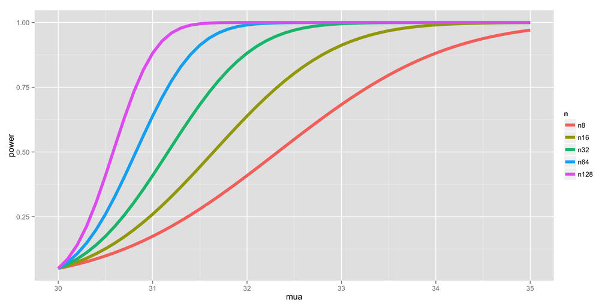

## Graphical Depiction of Power

```r
library(manipulate)
mu0 = 30
myplot <- function(sigma, mua, n, alpha){
    g = ggplot(data.frame(mu = c(27, 36)), aes(x = mu))
    g = g + stat_function(fun=dnorm, geom = "line",
                          args = list(mean = mu0, sd = sigma / sqrt(n)),
                          size = 2, col = "red")
    g = g + stat_function(fun=dnorm, geom = "line",
                          args = list(mean = mua, sd = sigma / sqrt(n)),
                          size = 2, col = "blue")
    xitc = mu0 + qnorm(1 - alpha) * sigma / sqrt(n)
    g = g + geom_vline(xintercept=xitc, size = 3)
    g
}
manipulate(
    myplot(sigma, mua, n, alpha),
    sigma = slider(1, 10, step = 1, initial = 4),
    mua = slider(30, 35, step = 1, initial = 32),
    n = slider(1, 50, step = 1, initial = 16),
    alpha = slider(0.01, 0.1, step = 0.01, initial = 0.05)
    )
```

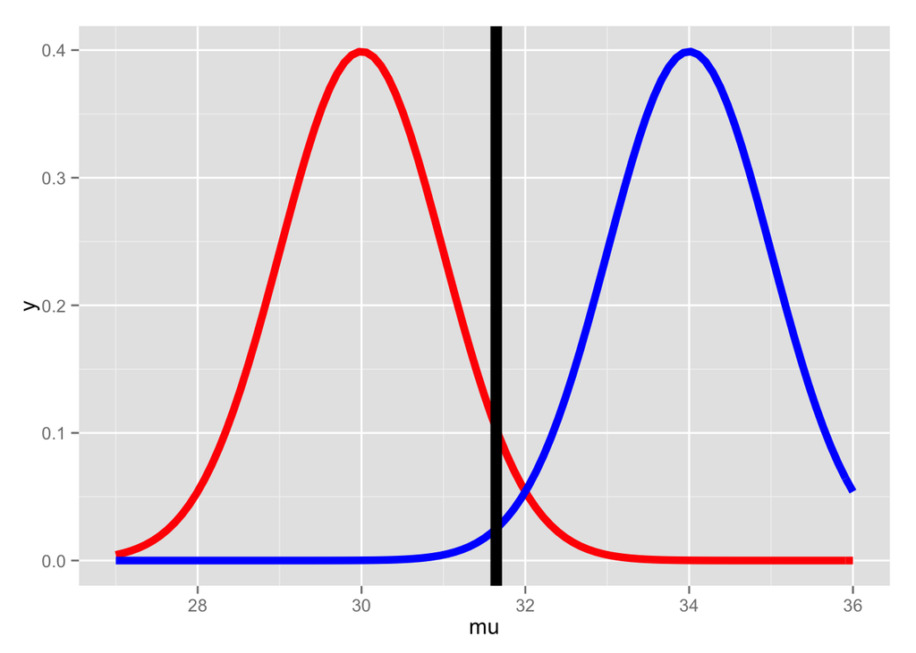

```r
g = ggplot(data.frame(mu = c(27, 36)), aes(x = mu))
g = g + stat_function(fun=dnorm, geom = "line",
                      args = list(mean = mu0, sd = sigma / sqrt(n)),
                      size = 2, col = "red")
g = g + stat_function(fun=dnorm, geom = "line",
                      args = list(mean = 34, sd = sigma / sqrt(n)),
                      size = 2, col = "blue")
xitc = mu0 + qnorm(1 - alpha) * sigma / sqrt(n)
g = g + geom_vline(xintercept=xitc, size = 3)
g
```

## Question

- When testing $H_a : \mu > \mu_0$, notice if power is $1 - \beta$, then $1 - \beta = P\left(\bar X > \mu_0 + z_{1-\alpha} \frac{\sigma}{\sqrt{n}} ; \mu = \mu_a \right)$
- where $\bar X \sim N(\mu_a, \sigma^2 / n)$
- Unknowns: $\mu_a$, $\sigma$, $n$, $\beta$
- Knowns: $\mu_0$, $\alpha$
- Specify any 3 of the unknowns and you can solve for the remainder

## Notes

- The calculation for $H_a:\mu < \mu_0$ is similar
- For $H_a: \mu \neq \mu_0$ calculate the one sided power using $\alpha / 2$ (this is only approximately right, it excludes the probability of getting a large TS in the opposite direction of the truth)
- Power goes up as $\alpha$ gets larger
- Power of a one sided test is greater than the power of the associated two sided test
- Power goes up as $\mu_1$ gets further away from $\mu_0$
- Power goes up as $n$ goes up
- Power doesn’t need $\mu_a$, $\sigma$ and $n$, instead only $\frac{\sqrt{n}(\mu_a - \mu_0)}{\sigma}$
- The quantity $\frac{\mu_a - \mu_0}{\sigma}$ is called the effect size, the difference in the means in standard deviation units.
- Being unit free, it has some hope of interpretability across settings

## T-test power

- Consider calculating power for a Gossett’s $T$ test for our example
- The power is $P\left(\frac{\bar X - \mu_0}{S /\sqrt{n}} > t_{1-\alpha, n-1} ~;~ \mu = \mu_a \right)$
- Calculating this requires the non-central t distribution.
- `power.t.test` does this very well
- Omit one of the arguments and it solves for it

## Example

You can monkey around with delta and sd, since it is the effect size (delta/sd) that is important. Delta = (meanA - mean0)

```r
power.t.test(n = 16, delta = 2 / 4, sd=1, type = "one.sample",  alt = "one.sided")$power
```

```
## [1] 0.6040329
```

```r
power.t.test(n = 16, delta = 2, sd=4, type = "one.sample",  alt = "one.sided")$power
```

```
## [1] 0.6040329
```

```r
power.t.test(n = 16, delta = 100, sd=200, type = "one.sample", alt = "one.sided")$power
```

```
## [1] 0.6040329
```

## Example

Now, for 3 ways to say the effect size, get the n you need for a given power.

```r
power.t.test(power = .8, delta = 2 / 4, sd=1, type = "one.sample",  alt = "one.sided")$n
```

```
## [1] 26.13751
```

```r
power.t.test(power = .8, delta = 2, sd=4, type = "one.sample",  alt = "one.sided")$n
```

```
## [1] 26.13751
```

```r
power.t.test(power = .8, delta = 100, sd=200, type = "one.sample", alt = "one.sided")$n
```

```
## [1] 26.13751
```

```r
ceiling(power.t.test(power = .8, delta = 100, sd=200, type="one.sample", alt = "one.sided")$n)
```

```
## [1] 27
```

```r
power.t.test(power = .8, sd=4, n = 27, type="one.sample", alt = "one.sided")$delta
```

```
## [1] 1.965942
```

```r
power.t.test(power = .8, delta=2, n = 27, sd=NULL, type="one.sample", alt="one.sided")$sd
```

```
## [1] 4.069293
```

# Multiple Testing

## Key ideas

- Hypothesis testing/significance analysis is commonly overused
- Correcting for multiple testing avoids false positives or discoveries
- Two key components
- Error measure
- Correction

## Three eras of statistics

**The age of Quetelet and his successors, in which huge census-level data sets were brought to bear on simple but important questions**: Are there more male than female births? Is the rate of insanity rising?

The classical period of Pearson, Fisher, Neyman, Hotelling, and their successors, intellectual giants who **developed a theory of optimal inference capable of wringing every drop of information out of a scientific experiment**. The questions dealt with still tended to be simple Is treatment A better than treatment B?

**The era of scientific mass production**, in which new technologies typified by the microarray allow a single team of scientists to produce data sets of a size Quetelet would envy. But now the flood of data is accompanied by a deluge of questions, perhaps thousands of estimates or hypothesis tests that the statistician is charged with answering together; not at all what the classical masters had in mind. Which variables matter among the thousands measured? How do you relate unrelated information?

http://www-stat.stanford.edu/~ckirby/brad/papers/2010LSIexcerpt.pdf

## Reasons for multiple testing

- molecular sequencing machines
- mri scanner
- fit bits
- other ways of collecting TONS of data

## Why correct for multiple tests?

- Jelly Beans cause acne! Scientists investigate! But we’re playing minecraft! Fine…
- We found no link for (purple, red, blue.)
- Green has a 0.05% link
- Green Jelly beans linked to Acne!

But if you test 20 things and then cherry pick the one that has a wanted answer, you have cheated. That is, you expect to find at least one error in 20 95% hypothesis tests.

http://xkcd.com/882/

## Types of errors

Suppose you are testing a hypothesis that a parameter $\beta$ equals zero versus the alternative that it does not equal zero. These are the possible outcomes.

|  | $\beta=0$ | $\beta\neq0$ | Hypotheses |
| --- | --- | --- | --- |
| Claim $\beta=0$ | $U$ | $T$ | $m-R$ |
| Claim $\beta\neq 0$ | $V$ | $S$ | $R$ |
| Claims | $m_0$ | $m-m_0$ | $m$ |

**Type I error or false positive ($V$)** Say that the parameter does not equal zero when it does

**Type II error or false negative ($T$)** Say that the parameter equals zero when it doesn’t

Which error rate you care about depends on the relative cost of the different errors, not diagnosing sometone versus (type II Bad) jailing an innocent man (type I bad), for instance

## Error rates

**False positive rate** - The rate at which false results ($\beta = 0$) are called significant: $E\left[\frac{V}{m_0}\right]$*

**Family wise error rate (FWER)** - The probability of at least one false positive ${\rm Pr}(V \geq 1)$

**False discovery rate (FDR)** - The rate at which claims of significance are false $E\left[\frac{V}{R}\right]$

- The false positive rate is closely related to the type I error rate http://en.wikipedia.org/wiki/False_positive_rate

## Controlling the false positive rate

If P-values are correctly calculated calling all $P < \alpha$ significant will control the false positive rate at level $\alpha$ on average.

Problem: Suppose that you perform 10,000 tests and $\beta = 0$ for all of them.

Suppose that you call all $P < 0.05$ significant.

The expected number of false positives is: $10,000 \times 0.05 = 500$ false positives. (Extreme in healt, common in signal processing)

**How do we avoid so many false positives?**

## Controlling family-wise error rate (FWER)

Control the probability that making even one error is less than alpha.

The [Bonferroni correction](http://en.wikipedia.org/wiki/Bonferroni_correction) is the oldest multiple testing correction.

**Basic idea**:

- Suppose you do $m$ tests
- You want to control FWER at level $\alpha$ so $Pr(V \geq 1) < \alpha$
- Calculate P-values normally
- Set $\alpha_{fwer} = \alpha/m$
- Call all $P$-values less than $\alpha_{fwer}$ significant

**Pros**: Easy to calculate, conservative

**Cons**: May be very conservative

## Controlling false discovery rate (FDR)

This is the most popular correction when performing *lots* of tests say in genomics, imaging, astronomy, or other signal-processing disciplines.

**Basic idea**:

- Suppose you do $m$ tests
- You want to control FDR at level $\alpha$ so $E\left[\frac{V}{R}\right]$
- Calculate P-values normally
- Order the P-values from smallest to largest $P_{(1)},...,P_{(m)}$
- Call any $P_{(i)} \leq \alpha \times \frac{i}{m}$ significant

**Pros**: Still pretty easy to calculate, less conservative (maybe much less)

**Cons**: Allows for more false positives, may behave strangely under dependence

## Example with 10 P-values

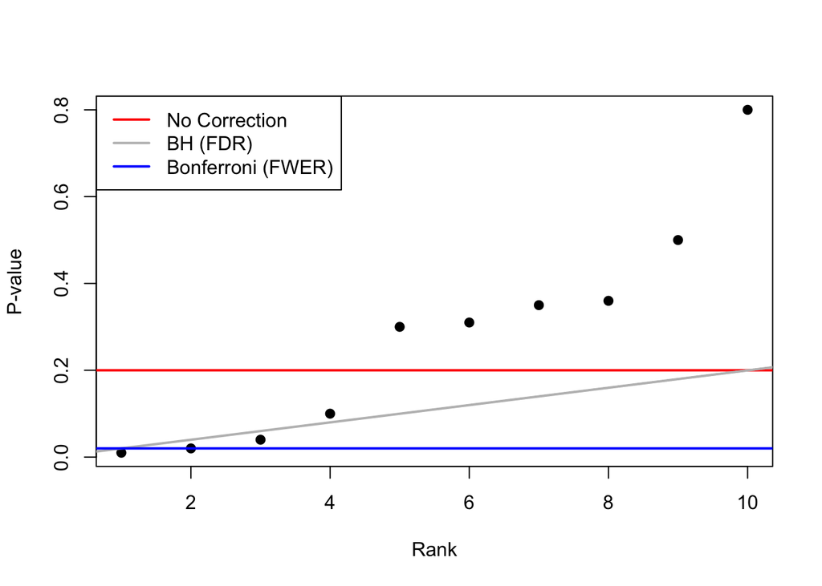

```r
par(mfrow=c (1,1))
pvalues <- c(0.01, 0.02, 0.04, 0.1, 0.30, 0.31, 0.35,
             0.36, 0.5, 0.8)
plot(pvalues, pch=19, xlab="Rank", ylab="P-value")
abline(h=.2, col="red", lwd=2)
abline(0, .2/10, col="gray", lwd=2)
abline(h = 0.2/10, col="blue", lwd=2)
legend(x="topleft", legend=c("No Correction", "BH (FDR)", "Bonferroni (FWER)"), col=c("red", "gray", "blue"), lty=rep(1, 3), lwd=rep(2, 3))
```

Controlling all error rates at $\alpha = 0.20$

## Adjusted P-values

- One approach is to adjust the threshold $\alpha$
- A different approach is to calculate “adjusted p-values”
- They *are not p-values* anymore
- But they can be used directly without adjusting $\alpha$

## Case study I: no true positives

```r
set.seed(1010093)
pValues <- rep(NA,1000)
for(i in 1:1000){
  y <- rnorm(20)
  x <- rnorm(20)
  pValues[i] <- summary(lm(y ~ x))$coeff[2,4]
}

# Controls false positive rate
sum(pValues < 0.05)
```

```
## [1] 51
```

## Case study I: no true positives

```r
# Controls FWER
sum(p.adjust(pValues,method="bonferroni") < 0.05)
```

```
## [1] 0
```

```r
# Controls FDR
sum(p.adjust(pValues,method="BH") < 0.05)
```

```
## [1] 0
```

## Case study II: 50% true positives

```r
set.seed(1010093)
pValues <- rep(NA,1000)
for(i in 1:1000){
  x <- rnorm(20)
  # First 500 beta=0, last 500 beta=2
  if(i <= 500){y <- rnorm(20)}else{ y <- rnorm(20,mean=2*x)}
  pValues[i] <- summary(lm(y ~ x))$coeff[2,4]
}
trueStatus <- rep(c("zero","not zero"),each=500)
table(pValues < 0.05, trueStatus)
```

```
##        trueStatus
##         not zero zero
##   FALSE        0  476
##   TRUE       500   24
```

## Case study II: 50% true positives

```r
# Controls FWER
table(p.adjust(pValues,method="bonferroni") < 0.05,trueStatus)
```

```
##        trueStatus
##         not zero zero
##   FALSE       23  500
##   TRUE       477    0
```

```r
# Controls FDR
table(p.adjust(pValues,method="BH") < 0.05,trueStatus)
```

```
##        trueStatus
##         not zero zero
##   FALSE        0  487
##   TRUE       500   13
```

## Case study II: 50% true positives

**P-values versus adjusted P-values**

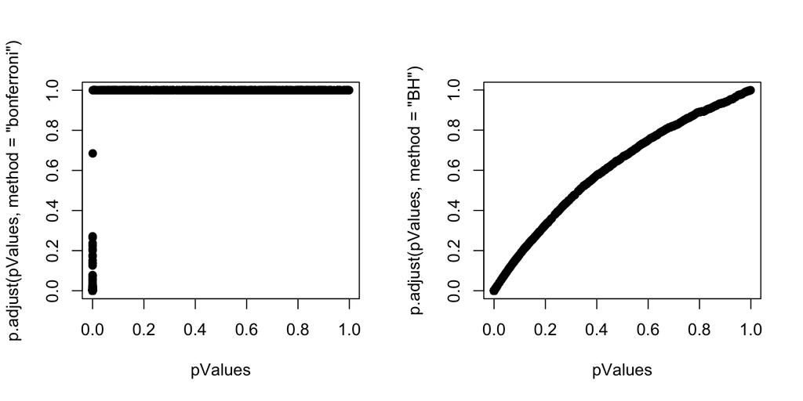

```r
par(mfrow=c(1,2))
plot(pValues,p.adjust(pValues,method="bonferroni"),pch=19)
plot(pValues,p.adjust(pValues,method="BH"),pch=19)
```

## Notes and resources

**Notes**:

- Multiple testing is an entire subfield
- A basic Bonferroni/BH correction is usually enough
- If there is strong dependence between tests there may be problems
- Consider method=“BY”

**Further resources**:

- [Multiple testing procedures with applications to genomics](http://www.amazon.com/Multiple-Procedures-Applications-Genomics-Statistics/dp/0387493166/ref=sr_1_2/102-3292576-129059?ie=UTF8&s=books&qid=1187394873&sr=1-2)
- [Statistical significance for genome-wide studies](http://www.pnas.org/content/100/16/9440.full)
- [Introduction to multiple testing](http://ies.ed.gov/ncee/pubs/20084018/app_b.asp)

# Resampling

## The bootstrap

- The bootstrap is a tremendously useful tool for constructing confidence intervals and calculating standard errors for difficult statistics
- For example, how would one derive a confidence interval for the median?
- The bootstrap procedure follows from the so called bootstrap principle

## Sample of 50 die rolls

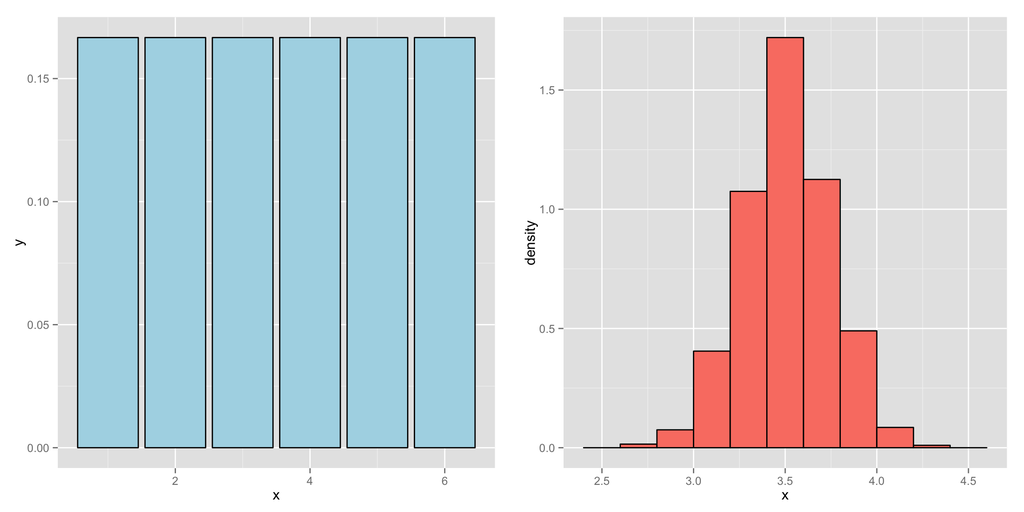

## What if we only had one sample?

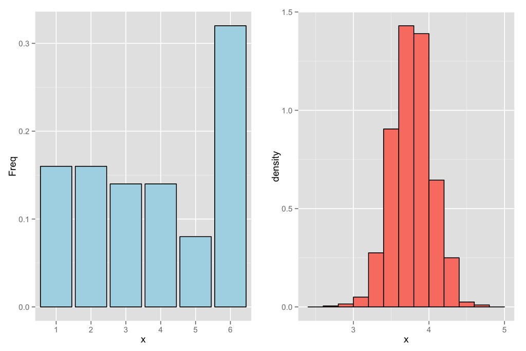

## Consider a data set

```r
library(UsingR)
data(father.son)
x <- father.son$sheight
n <- length(x)
B <- 10000
resamples <- matrix(sample(x,
                           n * B,
                           replace = TRUE),
                    B, n)
resampledMedians <- apply(resamples, 1, median)
```

## A plot of the histrogram of the resamples

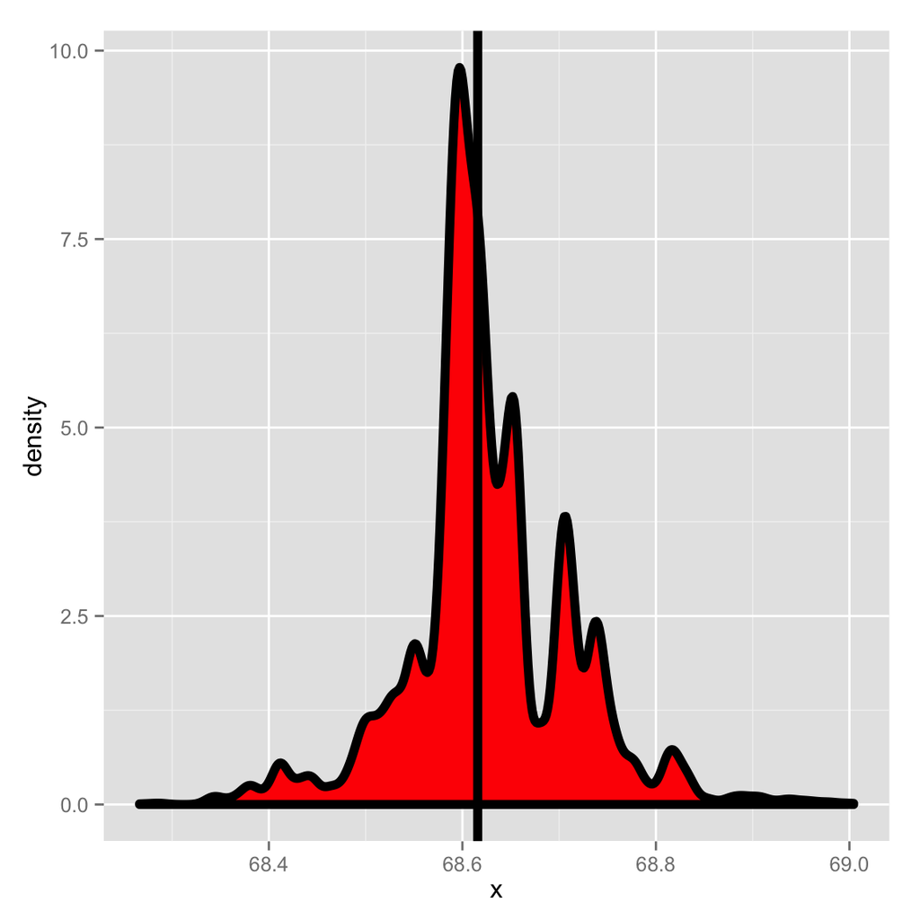

## The bootstrap principle

- Suppose that I have a statistic that estimates some population parameter, but I don’t know its sampling distribution
- The bootstrap principle suggests using the distribution defined by the data to approximate its sampling distribution

## The bootstrap in practice

- In practice, the bootstrap principle is always carried out using simulation
- We will cover only a few aspects of bootstrap resampling
- The general procedure follows by first simulating complete data sets from the observed data with replacement
- This is approximately drawing from the sampling distribution of that statistic, at least as far as the data is able to approximate the true population distribution
- Calculate the statistic for each simulated data set
- Use the simulated statistics to either define a confidence interval or take the standard deviation to calculate a standard error

## Nonparametric bootstrap algorithm example

- Bootstrap procedure for calculating confidence interval for the median from a data set of $n$ observations
1. Sample $n$ observations **with replacement** from the observed data resulting in one simulated complete data set
2. Take the median of the simulated data set
3. Repeat these two steps $B$ times, resulting in $B$ simulated medians
4. These medians are approximately drawn from the sampling distribution of the median of $n$ observations; therefore we can
   - Draw a histogram of them
   - Calculate their standard deviation to estimate the standard error of the median
   - Take the $2.5^{th}$ and $97.5^{th}$ percentiles as a confidence interval for the median

## Example code

```r
B <- 10000
resamples <- matrix(sample(x,
                           n * B,
                           replace = TRUE),
                    B, n)
medians <- apply(resamples, 1, median)
sd(medians)
```

```
## [1] 0.08262171
```

```r
quantile(medians, c(.025, .975))
```

```
##     2.5%    97.5%
## 68.44665 68.81461
```

## Histogram of bootstrap resamples

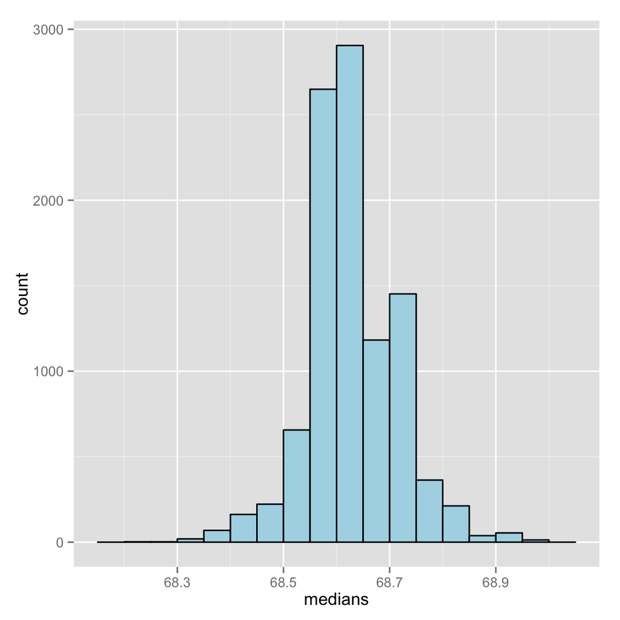

```r
g = ggplot(data.frame(medians = medians), aes(x = medians))
g = g + geom_histogram(color = "black", fill = "lightblue", binwidth = 0.05)
g
```

## Notes on the bootstrap

- The bootstrap is non-parametric
- Better percentile bootstrap confidence intervals correct for bias
- There are lots of variations on bootstrap procedures; the book “An Introduction to the Bootstrap”" by Efron and Tibshirani is a great place to start for both bootstrap and jackknife information

## Group comparisons

- Consider comparing two independent groups.
- Example, comparing sprays B and C

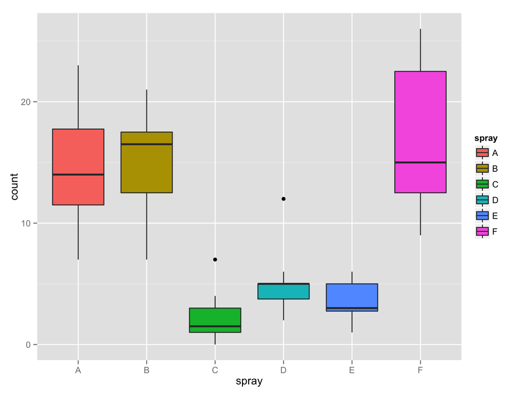

## Permutation tests

- Consider the null hypothesis that the distribution of the observations from each group is the same
- Then, the group labels are irrelevant
- Consider a data frome with count and spray
- Permute the spray (group) labels
- Recalculate the statistic
- Mean difference in counts
- Geometric means
- T statistic
- Calculate the percentage of simulations where the simulated statistic was more extreme (toward the alternative) than the observed

## Variations on permutation testing

| Data type | Statistic | Test name |
| --- | --- | --- |
| Ranks | rank sum | rank sum test |
| Binary | hypergeometric prob | Fisher’s exact test |
| Raw data |  | ordinary permutation test |

- Also, so-called *randomization tests* are exactly permutation tests, with a different motivation.
- For matched data, one can randomize the signs
- For ranks, this results in the signed rank test
- Permutation strategies work for regression as well
- Permuting a regressor of interest
- Permutation tests work very well in multivariate settings

## Permutation test B v C

```r
subdata <- InsectSprays[InsectSprays$spray %in% c("B", "C"),]
y <- subdata$count
group <- as.character(subdata$spray)
testStat <- function(w, g) mean(w[g == "B"]) - mean(w[g == "C"])
observedStat <- testStat(y, group)
permutations <- sapply(1 : 10000, function(i) testStat(y, sample(group)))
observedStat
```

```
## [1] 13.25
```

```r
mean(permutations > observedStat)
```

```
## [1] 0
```

## Histogram of permutations B v C

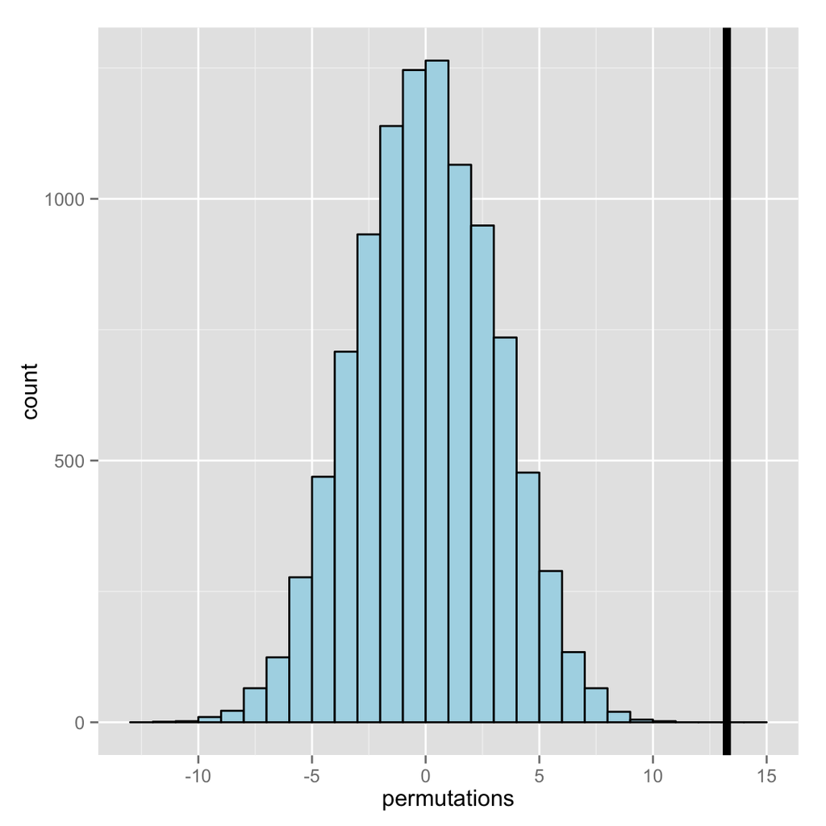